# lab3_Bazavluk

## "Лабораторна робота №3. Аналіз складності алгоритмів. Алгоритми сортування"

зробив Базавлук Руслан

**Мета:** *Освоїти аналіз складності алгоритмів як технологію на прикладі алгоритмів сортування методами вставляння та бульбашки.*

**Завдання для самостійной роботи**:

3: Складність методу сортування вставкою($O(n^2)$) Складність методу сортування бульбашкорю($O(n^2)$)

```python
##4 Завдання, метод сортування бульбашкою на Python
def Bubble(nums):
 swapped = True
 while swapped:
     swapped = False
     b = 0
     for i in range(len(a) - b - 1):
         if a[i] > a[i+1]:
             swapped = True
             a[i], a[i+1] = a[i+1], a[i]
             b = b + 1

def insertion_sort(nums):
    for j in range(1, len(nums)):
        key = nums[j]
        i = j - 1
        while i >= 0 and nums[i] > key:
            nums[i + 1] = nums[i]
            i -= 1
        nums[i + 1] = key

a = [8, 10, 6, 2, 4]
Bubble(a)
print(a)
```

```
[2, 4, 6, 8, 10]
```

```
Час сортування 5 елементів бульбашкою: 0.0
Час сортування 5 елементів вставкою: 0.0
Час сортування 10 елементів бульбашкою: 0.0
Час сортування 10 елементів вставкою: 0.0
Час сортування 50 елементів бульбашкою: 0.0
Час сортування 50 елементів вставкою: 0.0
Час сортування 100 елементів бульбашкою: 0.0
Час сортування 100 елементів вставкою: 0.0
Час сортування 500 елементів бульбашкою: 0.0
Час сортування 500 елементів вставкою: 0.004996538162231445
Час сортування 1000 елементів бульбашкою: 0.0
Час сортування 1000 елементів вставкою: 0.021367549896240234
Час сортування 2000 елементів бульбашкою: 0.0
Час сортування 2000 елементів вставкою: 0.09057855606079102
Час сортування 3000 елементів бульбашкою: 0.0
Час сортування 3000 елементів вставкою: 0.20434355735778809
Час сортування 4000 елементів бульбашкою: 0.0
Час сортування 4000 елементів вставкою: 0.3643362522125244
Час сортування 5000 елементів бульбашкою: 0.0009992122650146484
Час сортування 5000 елементів вставкою: 0.5595276355743408
Час бульбашкового сортування: [0.0, 0.0, 0.0, 0.0, 0.0, 0.0, 0.0, 0.0, 0.0, 0.0009992122650146484]
Час сортування вставкою: [0.0, 0.0, 0.0, 0.0, 0.004996538162231445, 0.021367549896240234, 0.09057855606079102, 0.20434355735778809, 0.3643362522125244, 0.5595276355743408]
```

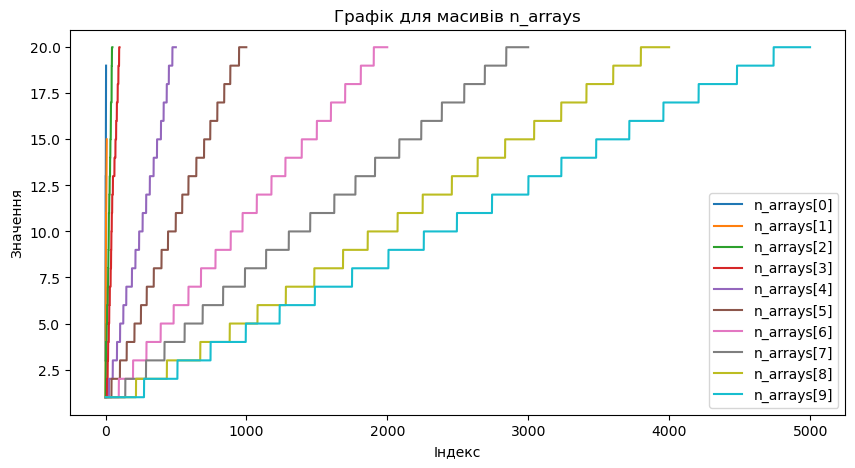

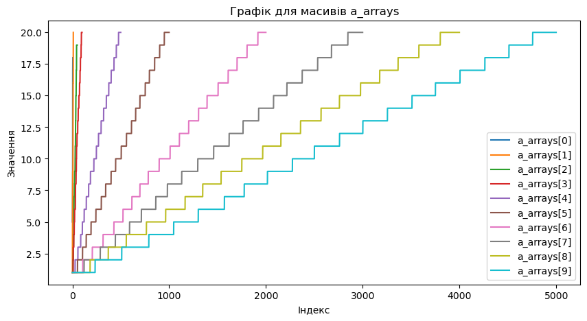

```python
import time
import random
import matplotlib.pyplot as plt
%matplotlib inline

def bubble(nums):
    swapped = True
    a = 0
    while swapped:
        swapped = False
        for i in range(len(nums) - a - 1):
            a += 1
            if nums[i] > nums[i + 1]:
                nums[i], nums[i + 1] = nums[i + 1], nums[i]
                swapped = True

def insertion_sort(nums):
    for j in range(1, len(nums)):
        key = nums[j]
        i = j - 1
        while i >= 0 and nums[i] > key:
            nums[i + 1] = nums[i]
            i -= 1
        nums[i + 1] = key


n_arrays = []
a_arrays = []
sizes = [5, 10, 50, 100, 500, 1000, 2000, 3000, 4000, 5000]  # Розміри масивів
for size in sizes:
    n_arrays.append([random.randint(1, 20) for _ in range(size)])
    a_arrays.append([random.randint(1, 20) for _ in range(size)])

ttome = []
tome = []
for i in range(len(sizes)):
    start_time = time.time()
    bubble(n_arrays[i])
    elapsed_time = time.time() - start_time
    print(f"Час сортування {sizes[i]} елементів бульбашкою: {elapsed_time}")
    ttome.append(elapsed_time)

    start_time = time.time()
    insertion_sort(a_arrays[i])
    elapsed_time = time.time() - start_time
    print(f"Час сортування {sizes[i]} елементів вставкою: {elapsed_time}")
    tome.append(elapsed_time)

print("Час бульбашкового сортування:", ttome)
print("Час сортування вставкою:", tome)

plt.figure(figsize=(10, 5))
for i, array in enumerate(n_arrays):
    plt.plot(sorted(array), label=f'n_arrays[{i}]')
plt.title('Графік для масивів n_arrays')
plt.xlabel('Індекс')
plt.ylabel('Значення')
plt.legend()
plt.show()

plt.figure(figsize=(10, 5))
for i, array in enumerate(a_arrays):
    plt.plot(sorted(array), label=f'a_arrays[{i}]')
plt.title('Графік для масивів a_arrays')
plt.xlabel('Індекс')
plt.ylabel('Значення')
plt.legend()
plt.show()
```

## Контрольні питання

1. Що таке $O-нотація$ і чим вона відрізняється від $\Omega-нотації$?

   $O-нотація$ - це верхня межа, $\Omega-нотації$ - нижня
2. Яку часову складність має алгоритм сортування методом вставки за найсприятливішої умови, коли масив відсортовано? Відповідь обгрунтувати.

Алгоритм сортування методом вставки за найсприятливішої умови маж складність $O(n)$, бо алгоритм все рівно бере кожен елемент та перевіряє з іншими

3. Дати визначення ефективного алогоритму.

Ефективний алгоритм - це алгоритм, який працює швидко то ефективно використовує ресурс уя вирішенія конкретної задачі

4.. Пояснити поняття головного параметра (розміру) задачі

Головний параметр (розмір) задачі - це об'єм даних, який визначає складність виконання алгоритму..

5.. Функція часової складності має вигляд: $F(N)=N^3+7N^2-14N$. Як записати аисмптотичну складність в нотації $O()$